# Průzkumná analýza dat: Cvičení

Kateřina Večerková vecerkok@vscht.cz

2025-06-26

# Cvičení

## Porozumění a shrnutí dat

### Cvičení 1: Načtení a náhled dat

**Úkol:** Načtěte dataset Titanic z CSV souboru a zobrazte prvních 10 řádků pro seznámení se s daty.

```r
library(tidyverse, quietly = TRUE)
data <- read.csv("titanic.csv")
head(data, n=10)
```

```
##    PassengerId Survived Pclass
## 1            1        0      3
## 2            2        1      1
## 3            3        1      3
## 4            4        1      1
## 5            5        0      3
## 6            6        0      3
## 7            7        0      1
## 8            8        0      3
## 9            9        1      3
## 10          10        1      2
##                                                   Name    Sex Age SibSp Parch
## 1                              Braund, Mr. Owen Harris   male  22     1     0
## 2  Cumings, Mrs. John Bradley (Florence Briggs Thayer) female  38     1     0
## 3                               Heikkinen, Miss. Laina female  26     0     0
```

[output cut: 18 more lines]

### Cvičení 2: Struktura dat a souhrnné statistiky

**Úkol:**

1. Použijte funkci `str()`, abyste prozkoumali strukturu dat a zjistili datové typy jednotlivých sloupců.
2. Získejte souhrn všech proměnných pomocí `summary()`. Identifikujte zajímavé hodnoty nebo možné odlehlé body.

```r
str(data)
```

```
## 'data.frame':    891 obs. of  12 variables:
##  $ PassengerId: int  1 2 3 4 5 6 7 8 9 10 ...
##  $ Survived   : int  0 1 1 1 0 0 0 0 1 1 ...
##  $ Pclass     : int  3 1 3 1 3 3 1 3 3 2 ...
##  $ Name       : chr  "Braund, Mr. Owen Harris" "Cumings, Mrs. John Bradley (Florence Briggs Thayer)" "Heikkinen, Miss. Laina" "Futrelle, Mrs. Jacques Heath (Lily May Peel)" ...
##  $ Sex        : chr  "male" "female" "female" "female" ...
##  $ Age        : num  22 38 26 35 35 NA 54 2 27 14 ...
##  $ SibSp      : int  1 1 0 1 0 0 0 3 0 1 ...
##  $ Parch      : int  0 0 0 0 0 0 0 1 2 0 ...
##  $ Ticket     : chr  "A/5 21171" "PC 17599" "STON/O2. 3101282" "113803" ...
##  $ Fare       : num  7.25 71.28 7.92 53.1 8.05 ...
##  $ Cabin      : chr  "" "C85" "" "C123" ...
##  $ Embarked   : chr  "S" "C" "S" "S" ...
```

```r
summary(data)
```

```
##   PassengerId       Survived          Pclass          Name
##  Min.   :  1.0   Min.   :0.0000   Min.   :1.000   Length:891
##  1st Qu.:223.5   1st Qu.:0.0000   1st Qu.:2.000   Class :character
##  Median :446.0   Median :0.0000   Median :3.000   Mode  :character
##  Mean   :446.0   Mean   :0.3838   Mean   :2.309
##  3rd Qu.:668.5   3rd Qu.:1.0000   3rd Qu.:3.000
##  Max.   :891.0   Max.   :1.0000   Max.   :3.000
##
##      Sex                 Age            SibSp           Parch
##  Length:891         Min.   : 0.42   Min.   :0.000   Min.   :0.0000
##  Class :character   1st Qu.:20.12   1st Qu.:0.000   1st Qu.:0.0000
##  Mode  :character   Median :28.00   Median :0.000   Median :0.0000
##                     Mean   :29.70   Mean   :0.523   Mean   :0.3816
##                     3rd Qu.:38.00   3rd Qu.:1.000   3rd Qu.:0.0000
##                     Max.   :80.00   Max.   :8.000   Max.   :6.0000
##                     NA's   :177
##     Ticket               Fare           Cabin             Embarked
##  Length:891         Min.   :  0.00   Length:891         Length:891
##  Class :character   1st Qu.:  7.91   Class :character   Class :character
##  Mode  :character   Median : 14.45   Mode  :character   Mode  :character
##                     Mean   : 32.20
##                     3rd Qu.: 31.00
##                     Max.   :512.33
##
```

### Cvičení 3: Kontrola chybějících hodnot

**Úkol:** Použijte funkci `is.na()` k ověření přítomnosti chybějících hodnot. Shrňte, které sloupce obsahují chybějící hodnoty a jak často.

```r
colSums(is.na(data))
```

```
## PassengerId    Survived      Pclass        Name         Sex         Age
##           0           0           0           0           0         177
##       SibSp       Parch      Ticket        Fare       Cabin    Embarked
##           0           0           0           0           0           0
```

## Vizualizace klíčových proměnných

### Cvičení 4: Rozložení věku

**Úkol:** Vytvořte histogram pro sloupec `Age`, abyste porozuměli jeho rozložení. Zvolte vhodný počet intervalů (např. 20) a popište osy.

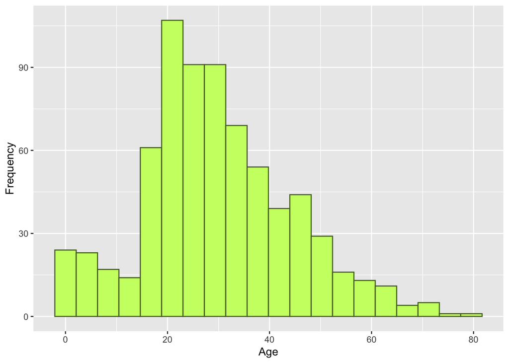

```r
library(ggplot2, quietly = TRUE)
ggplot(data, aes(x=Age)) + geom_histogram(bins = 20, color = "darkolivegreen", fill = "darkolivegreen1") + xlab("Age") + ylab("Frequency")
```

### Cvičení 5: Míra přežití podle pohlaví

**Úkol:** Vytvořte sloupcový graf, který zobrazí míru přežití (`Survived`) podle pohlaví (`Sex`). To pomůže porozumět vlivu pohlaví na přežití.

[figure not shown]

```r
ggplot(data, aes(x = Sex, y = Survived)) +
  geom_col(color = "orange3", fill = "orange2") +
  labs(title = "Barplot of Gender by Survived", x = "Survived", y = "Gender")
```

### Cvičení 6: Rozložení ceny podle třídy

**Úkol:** Vytvořte boxplot znázorňující rozložení `Fare` podle cestovní třídy (`Pclass`). Interpretujte, zda se ceny mezi třídami liší.

[figure not shown]

```r
ggplot(data, aes(x = as.factor(Pclass), y = Fare)) +
  geom_boxplot(fill = "tomato1") +
  labs(title = "Boxplot of Age by Survived", x = "Passenger Class", y = "Fare")
```

## Zpracování chybějících dat

### Cvičení 7: Imputace chybějícího věku

**Úkol:** Nahraďte chybějící hodnoty ve sloupci `Age` mediánem. Ověřte, že ve sloupci nezůstaly žádné chybějící hodnoty.

```r
# z histogramu výše vidíme, že rozdělení dat je zešikmené, proto budeme chybějící hodnoty nahrazovat mediánem sloupce
age_median <- median(data$Age, na.rm = TRUE)
data <- data %>% mutate(Age = replace_na(Age, age_median))

# zkontrolovat chybějící hodnoty po nahrazení
sum(is.na(data$Age))
```

```
## [1] 0
```

### Cvičení 8: Náhrada chybějících hodnot ve sloupci `Embarked`

**Úkol:** Nahraďte chybějící hodnoty ve sloupci `Embarked` nejčastěji se vyskytujícím přístavem. Zobrazte výsledek pro ověření změn.

```r
embarked_without_na <- data %>% select(Embarked) %>% drop_na()
frequency_table <- table(embarked_without_na)
embarked_mode <- names(frequency_table)[which.max(frequency_table)]
data <- data %>% mutate(Embarked = replace_na(Embarked, embarked_mode))

# zkontrolovat chybějící hodnoty po nahrazení
sum(is.na(data$Embarked))
```

```
## [1] 0
```

## Základní analýza vztahů

### Cvičení 9: Vztah mezi cenou a přežitím

**Úkol:** Vytvořte boxplot prozkoumávající vztah mezi `Fare` a `Survived`. Co tato vizualizace naznačuje o vlivu ceny na přežití?

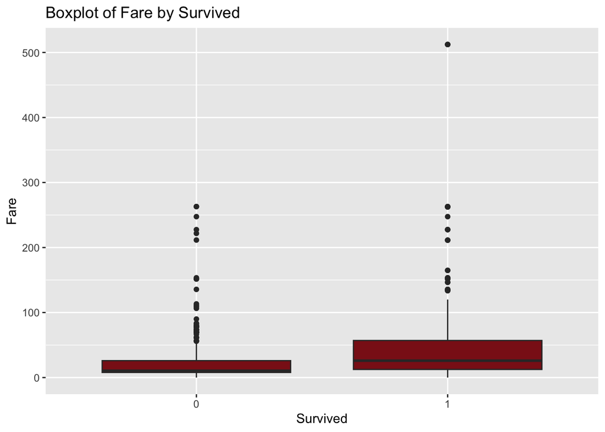

```r
ggplot(data, aes(x = as.factor(Survived), y = Fare)) +
  geom_boxplot(fill = "firebrick4") +
  labs(title = "Boxplot of Fare by Survived", x = "Survived", y = "Fare")
```